# Correction de l’exam blanc

[Retour à la page d’accueil](https://scortijo.github.io/2021_L3_R/)

## Préparation de l’environnement de travail

On charge le tidyverse et DT pour manipuler les dataframes, faire des graphiques, et représenter interactivement des tables.

```r
library(tidyverse)
library(DT)
library(visdat)
```

Ici, on utilise la fonction `read_tsv` qui est adaptée aux fichiers texte avec une tabulation comme séparateur.

```r
#expt1 <- read_tsv("2021_L3_R/session6_exam_blanc/data/data_expression_cortijo2017.txt")
# ou, pour des questions de chemin, si l'exam est dans le repertoire de la session6/materiel:

expt1 <- read_tsv("../data/data_expression_cortijo2017.txt")
```

## Vérification des données

#### Question 1

On utilise dim qui permet de voir le nombre de lignes et de colonnes d’u dataframe :

```r
dim(expt1)
```

```
## [1] 1035    8
```

On a bien 1035 lignes, donc 1035 gènes.

Pour vérifier les données contenues, on utilise une fonction qui va nous montrer le nom des colonnes :

```r
head(expt1)
```

```
## # A tibble: 6 x 8
##   gene      Log2FoldToZero_1~ TLog2FoldToZero~ Log2FoldToZero_~ Log2FoldToZero_~
##   <chr>                 <dbl>            <dbl>            <dbl>            <dbl>
## 1 AT1G01060           -0.205           -0.799           -3.19             -0.443
## 2 AT1G01390            0.336           -0.430           -1.01             -0.604
## 3 AT1G04520           -0.0924          -0.595           -1.44             -0.447
## 4 AT1G04530            0.153            0.0464          -0.106            -0.117
## 5 AT1G04770            0.0288           0.299           -0.952             0.649
## 6 AT1G05260           -0.291           -0.170            0.0144           -0.123
## # ... with 3 more variables: Log2FoldToZero_27c_1hr <dbl>,
## #   Log2FoldToZero_27c_4hr <dbl>, cluster <chr>
```

```r
#ou
names(expt1)
```

```
## [1] "gene"                     "Log2FoldToZero_17c_15min"
## [3] "TLog2FoldToZero_17c_1hr"  "Log2FoldToZero_17c_4hr"
## [5] "Log2FoldToZero_27c_15min" "Log2FoldToZero_27c_1hr"
## [7] "Log2FoldToZero_27c_4hr"   "cluster"
```

On a 8 colonnes :

- L’expression dans 6 conditions (en logFC)
- Une colonne avec le nom du gène
- Une colonne avec le cluster

#### Question 2

la fonction `glimpse` donne pour chaque colonne le type de donnée contenue (ou `visdat` qui donne cette info au format visuel):

```r
glimpse(expt1)
```

```
## Rows: 1,035
## Columns: 8
## $ gene                     <chr> "AT1G01060", "AT1G01390", "AT1G04520", "AT1G0~
## $ Log2FoldToZero_17c_15min <dbl> -0.20541474, 0.33632923, -0.09238742, 0.15326~
## $ TLog2FoldToZero_17c_1hr  <dbl> -0.79897351, -0.43001152, -0.59508697, 0.0463~
## $ Log2FoldToZero_17c_4hr   <dbl> -3.19412471, -1.00696077, -1.44063713, -0.105~
## $ Log2FoldToZero_27c_15min <dbl> -0.442671451, -0.603690351, -0.447488453, -0.~
## $ Log2FoldToZero_27c_1hr   <dbl> -1.7035956, -1.9411219, -1.7754923, -0.587857~
## $ Log2FoldToZero_27c_4hr   <dbl> -5.2605713, -1.8716159, -1.9339907, -0.754507~
## $ cluster                  <chr> "cluster1", "cluster1", "cluster1", "cluster1~
```

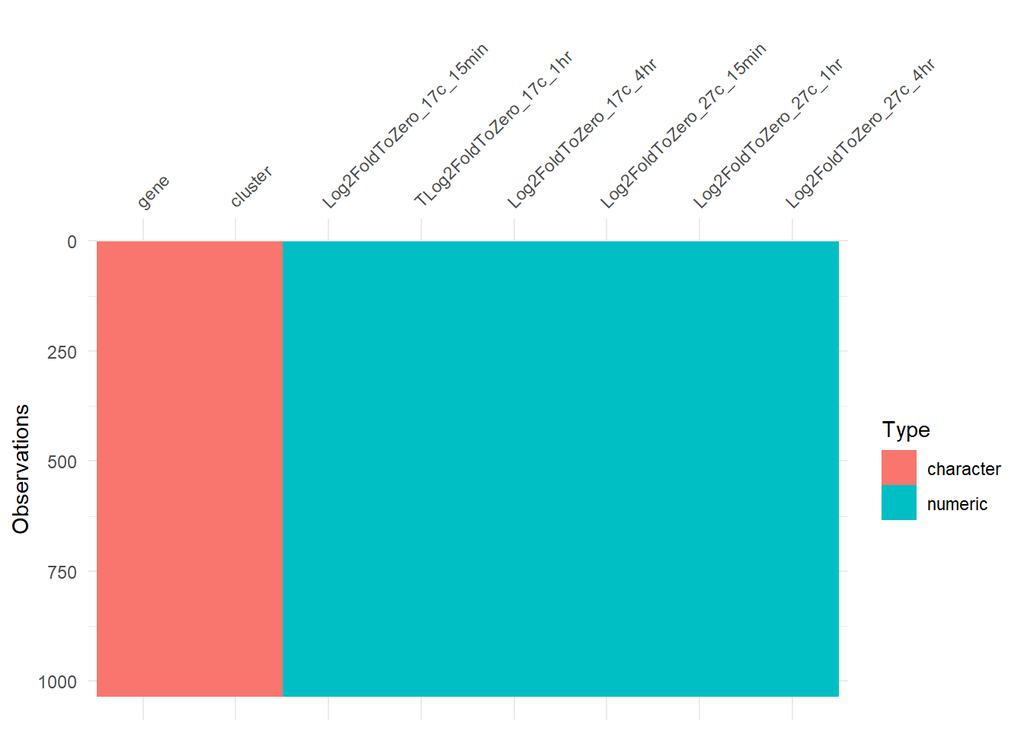

```r
# et/ou

vis_dat(expt1)
```

Les colonnes avec des valeurs d’expression sont des `dbl`, c’est à dire des nombres à virgule, tandis que les colonnes gene et cluster contiennent des `chr`, c’est à dire des chaines de charatères comme attendu.

#### Question 3

On voudrait savoir quels sont les différents clusters possibles. Pour cela, on va récupérer cette colonne et montrer les valeurs uniques qu’elle contient :

```r
unique(expt1$cluster)
```

```
## [1] "cluster1"  "cluster2"  "cluster3"  "cluster4"  "cluster5"  "cluster6A"
## [7] "cluster6B"
```

#### Question 4

Pour filtrer tout d’abord les données pour garder les deux gènes d’intérêt, on utilise `filter`, en demandant à ce que les valeurs de la colonne `gene` soient dans le vecteur `c("AT1G04520","AT3G12580")`.

Pour changer le format du tableau pour passer un format long avec une colonne contenant la condition experimentale et une colonne contenant les valeurs d’expression, on utilise `gather` sur les colonnes contenant l’expression dans les différentes conditions `Log2FoldToZero_17c_15min:Log2FoldToZero_27c_4hr`. On appelle la nouvelle clé est nommée `condition` et la colonne valeur est nommée `expression`.

Pour séparer la colonne des conditions expérimentales afin que la température et le temps du traitement soient dans deux colonnes différentes, c’est la fonction `separate` qu’il nous faut. Elle va découper les conditions de part et d’autre des underscores. On nomme les 3 nouvelles colonnes crées `"normalisation", "temperature", "temps"`.

On peut maintenant appeler `ggplot` pour tracer le graphique, qui aura en axis x le temps, en axe y l’expression. On ajoute dans la fonction `aes` que la couleur doit être liée à la température. Comme on souhaite représenter une ligne par température différente, il faut préciser un `aes` supplémentaire, `group`, qui sera également associé à la température.

On ajoute ensuite au ggplot la fonction `geom_line` pour tracer les lignes d’expression.

Enfin, pour faire sous graphe par gène, on ajoute un `facet_wrap` sur la colonne gène.

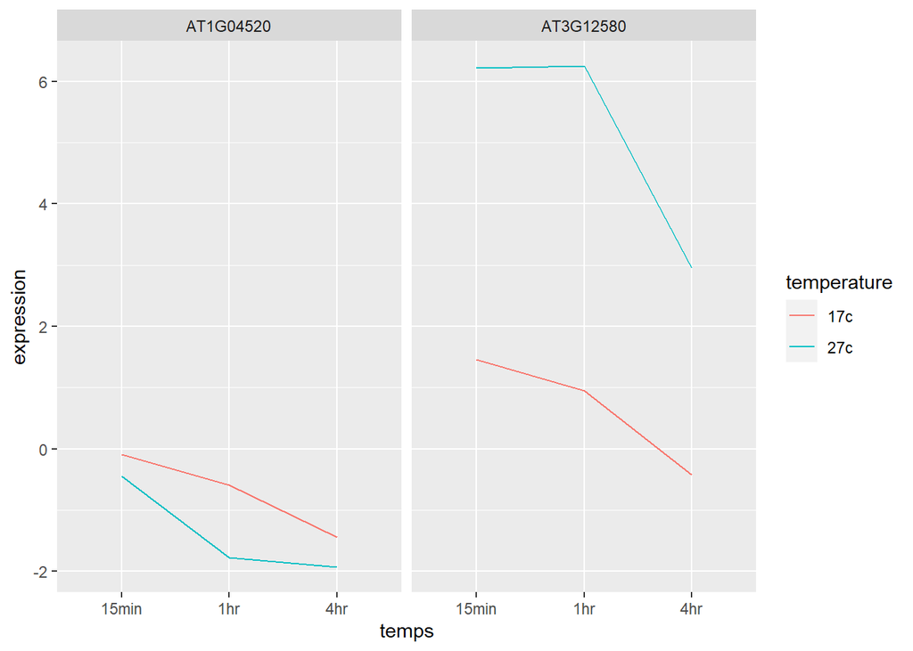

```r
filter(expt1, gene%in%c("AT1G04520","AT3G12580")) %>%
  gather(key="condition", value="expression", Log2FoldToZero_17c_15min:Log2FoldToZero_27c_4hr) %>%
  separate(condition, into=c("normalisation", "temperature", "temps")) %>%
  ggplot(aes(x=temps, y=expression,color=temperature, group=temperature)) +
  geom_line() +
  facet_wrap(~gene)
```

Pour AT1G04520, on observe bien que l’expression diminue au cours du temps à 17°C et 27°C et que cette diminution est plus rapide est plus importante à 27°C (ligne bleue).

Pour AT3G12580, on observe bien que l’expression augmente à 27°C de manière rapide et atteint son pic d’expression en 15 minutes avant de redescendre (ligne bleue). A 17°C, cette augmentation est présente mais moins forte (ligne rouge).

#### Question 5

```r
group_by(expt1, cluster) %>%
  summarise(n.obs=n())
```

```
## # A tibble: 7 x 2
##   cluster   n.obs
##   <chr>     <int>
## 1 cluster1    350
## 2 cluster2    193
## 3 cluster3    110
## 4 cluster4    130
## 5 cluster5    105
## 6 cluster6A   104
## 7 cluster6B    43
```

```r
# ou

table(expt1$cluster)
```

```
##
##  cluster1  cluster2  cluster3  cluster4  cluster5 cluster6A cluster6B
##       350       193       110       130       105       104        43
```

Alternativement, une fonction, `table` de la base de R permet également de faire cette opération.

#### Question 6

On peut maintenant appeler `ggplot` pour tracer le graphique, qui aura en axis x le temps, en axe y l’expression. On ajoute dans la fonction `aes` que la couleur de remplissage (`fill`) doit être liée à la température.

On ajoute ensuite la fonction `geom_violin`, puis un `facet_grid` sur la variable `cluster` car on veut un sous graphique pour chaque cluster.

Pour obtenir un boxplot, vous avez uniquement besoin de remplacer `geom_violin` par `geom_boxplot`.

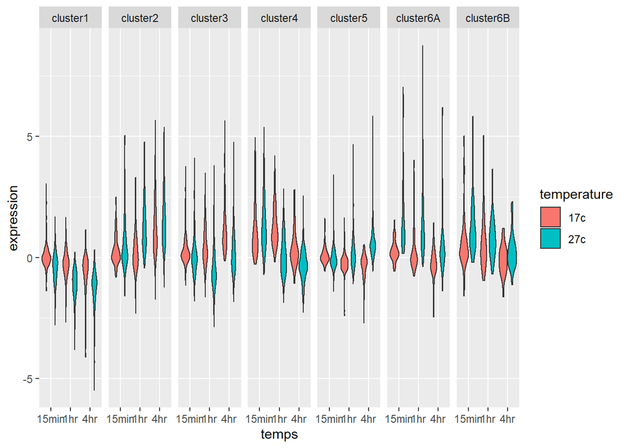

```r
gather(expt1, key="condition", value="expression", Log2FoldToZero_17c_15min:Log2FoldToZero_27c_4hr) %>%
  separate(condition, into=c("normalisation", "temperature", "temps")) %>%
  ggplot(aes(x=temps, y=expression, fill=temperature )) +
  geom_violin() +
  facet_grid(~cluster)
```

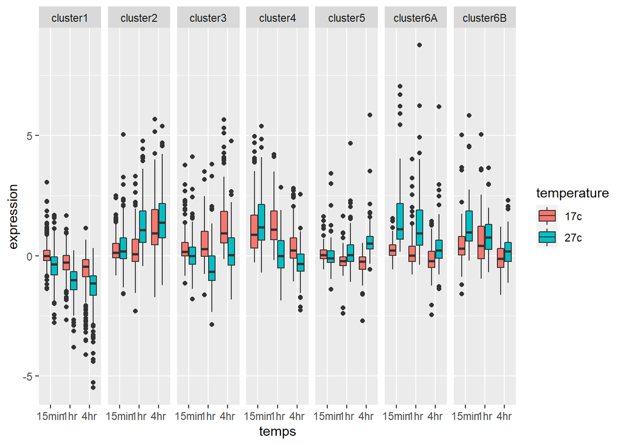

```r
gather(expt1, key="condition", value="expression", Log2FoldToZero_17c_15min:Log2FoldToZero_27c_4hr) %>%
  separate(condition, into=c("normalisation", "temperature", "temps")) %>%
  ggplot(aes(x=temps, y=expression, fill=temperature )) +
  geom_boxplot() +
  facet_grid(~cluster)
```

Un boxplot montre les **statistiques résumées** d’un groupe d’observations (médiane, premier quartile, et troisième quartile. Les points qui dépassent des boxplots sont les valeurs prédites comme “extrêmes”).

Un violin plot montre la **distribution** d’un groupe d’observations (la forme de cette distribution est plus précise et montre comment sont réparties les observations).

Utiliser un violin plot permet par exemple de contrôler qu’il n’y ait pas de distribution bimodale (deux pics dans la distribution) ce qui voudrait dire qu’il pourrait y avoir deux populations distinctes dans les observations récoltées. Pour comparer des groupes entre plusieurs conditions (comme la température), un boxplot est plus pratique car on peut par exemple comparer directement les médianes (trait central du boxplot).

Dans les **clusters 5, 6A et 6B**, on a une augmentation de l’expression à 27 °C comparé à 17 °C, il s’agit donc des gènes qui sont induits par une forte température.

Pour la réponse de la température au cours du temps, on constate une nette diminution de l’expression après transfert en condition de chaleur dans le **cluster 1**. Le log fold change est inférieur à 0, ce qui veut dire qu’on a une expression moins forte après un certain temps passé à 27 °C comparé à avant le transfert, et cette diminution d’expression s’accentue plus les plantes sont exposées à la chaleur longtemps (l’expression continue de chuter jusqu’à 4h).

#### Question 7

Ce graphique pourrait être fortement amélioré pour une recherche plus reproductible.

En particulier, on pourrait lui rajouter :

- Un *titre* (précisant par exemple que l’expression est un log fold change entre le temps d’intérêt et le temps 0)
- Le *nombre d’observations* par boxplot (c’est à dire le nombre de gènes dans les clusters).

#### Question 8

Pour ces nouvelles données, on utilise la fonction `read_tsv` qui est adaptée aux fichiers textes avec une tabulation comme séparateur.

```r
gene_fonction <- read_tsv("../data/gene_fonction_cortijo2017.txt")
```

Ici, on veut créer un nouveau tableau de données qui sera la jointure de `gene_fonction` et `expt1`. Cette jointure de tableau de données se fait avec la fonction `inner_join` sur la base de la colonne `gene`, que les deux tableaux contiennent. Comme on ne veut pas les gènes qui ont une annotation mais qui ne seraient pas présents dans `expt1`, on utilise `inner_join` et non pas `outer_join` qui aurait conservé les gènes présentes dans au moins l’un des deux tableaux, mais pas les deux à la fois.

```r
gene_expression_fonction <- inner_join(gene_fonction, expt1, by="gene")
```

On utilise `filter` sur le nouveau dataframe, avec la fonction de test `gene=="AT3G12580"` qui garde uniquement le gène qui nous intéresse.

```r
filter(gene_expression_fonction, gene=="AT3G12580")
```

```
## # A tibble: 1 x 9
##   gene      Primary_Gene_Sym~ Log2FoldToZero_~ TLog2FoldToZero~ Log2FoldToZero_~
##   <chr>     <chr>                        <dbl>            <dbl>            <dbl>
## 1 AT3G12580 HEAT SHOCK PROTE~             1.46            0.951           -0.421
## # ... with 4 more variables: Log2FoldToZero_27c_15min <dbl>,
## #   Log2FoldToZero_27c_1hr <dbl>, Log2FoldToZero_27c_4hr <dbl>, cluster <chr>
```

La colonne rajoutée, nommée `Primary_Gene_Symbol` nous informe que ce gène est une protéine induite en réponse à un stress en chaleur (`HEAT SHOCK PROTEIN 70 (HSP70)`).

```r
filter(gene_expression_fonction, cluster=="cluster6A") %>%
  datatable(filter="top", options = list(pageLength = 20, scrollX=T))
```

|  | gene | Primary_Gene_Symbol | Log2FoldToZero_17c_15min | TLog2FoldToZero_17c_1hr | Log2FoldToZero_17c_4hr | Log2FoldToZero_27c_15min | Log2FoldToZero_27c_1hr | Log2FoldToZero_27c_4hr | cluster |
| --- | --- | --- | --- | --- | --- | --- | --- | --- | --- |
| 1 | AT1G10230 | SKP1-LIKE 18 (SK18) | -0.136096378 | -0.163976712 | -0.505577993 | 0.583938627 | 0.409797683 | 0.149761477 | cluster6A |
| 2 | AT1G10380 |  | 0.007637579 | 0.100299216 | 0.022497446 | 0.324825885 | 0.749196792 | 0.20763668 | cluster6A |
| 3 | AT1G11100 |  | 0.15579528 | -0.356245982 | 0.201873632 | 1.062500657 | 1.081208336 | 0.423407899 | cluster6A |
| 4 | AT1G18330 | EARLY-PHYTOCHROME-RESPONSIVE1 (EPR1) | -0.505737148 | -0.565088082 | 0.670166793 | 2.224709643 | 0.936564177 | 1.539156053 | cluster6A |
| 5 | AT1G30070 |  | 0.202056943 | -0.021599342 | -0.172438722 | 2.92730836 | 2.655537692 | 0.539928569 | cluster6A |
| 6 | AT1G31280 | ARGONAUTE 2 (AGO2) | 0.079577745 | -0.183574001 | -0.495911706 | 1.693154186 | 0.314900031 | -0.564362585 | cluster6A |
| 7 | AT1G35660 |  | -0.004489873 | -0.50169619 | -0.284163996 | 1.000567573 | 0.851678233 | 0.642256247 | cluster6A |
| 8 | AT1G44350 | IAA-LEUCINE RESISTANT (ILR)-LIKE GENE 6 (ILL6) | 0.22279768 | 2.533476506 | 1.351300941 | 1.176638192 | 2.394086803 | 1.640926872 | cluster6A |
| 9 | AT1G52560 |  | 0.918741958 | 1.349859995 | -0.218140557 | 3.129185537 | 4.01418905 | 0.816208897 | cluster6A |
| 10 | AT1G59124 |  | 0.263106387 | -0.014483805 | -0.294830064 | 0.667771573 | -0.225186096 | -0.036887014 | cluster6A |

[output cut: 94 more lines]

Cet affichage interactif doit vous permettre de chercher dans la table le terme “heat” et de compter combien de lignes apparaissent.

On remarque que 12 gènes ont une annotation contenant “heat” dans le cluster 6A.

Pour comparer au nombre d’occurrences de “heat” dans tous les gènes des données, on réutilise la même fonction mais sans le `filter` sur l’appartenance au cluster :

```r
datatable(gene_expression_fonction,filter="top", options = list(pageLength = 20, scrollX=T))
```

|  | gene | Primary_Gene_Symbol | Log2FoldToZero_17c_15min | TLog2FoldToZero_17c_1hr | Log2FoldToZero_17c_4hr | Log2FoldToZero_27c_15min | Log2FoldToZero_27c_1hr | Log2FoldToZero_27c_4hr | cluster |
| --- | --- | --- | --- | --- | --- | --- | --- | --- | --- |
| 1 | AT1G01060 | LATE ELONGATED HYPOCOTYL (LHY) | -0.205414743 | -0.798973513 | -3.194124711 | -0.442671451 | -1.703595633 | -5.260571295 | cluster1 |
| 2 | AT1G01390 |  | 0.336329225 | -0.430011522 | -1.006960774 | -0.603690351 | -1.941121879 | -1.871615892 | cluster1 |
| 3 | AT1G04520 | PLASMODESMATA-LOCATED PROTEIN 2 (PDLP2) | -0.09238742 | -0.595086966 | -1.440637133 | -0.447488453 | -1.775492345 | -1.933990692 | cluster1 |
| 4 | AT1G04530 | TETRATRICOPEPTIDE REPEAT 4 (TPR4) | 0.153264994 | 0.04638492 | -0.105687282 | -0.117490373 | -0.587857862 | -0.754507637 | cluster1 |
| 5 | AT1G04770 |  | 0.028761734 | 0.299317056 | -0.951783905 | 0.648822494 | -0.751944959 | -0.820340083 | cluster1 |
| 6 | AT1G05260 | RARE COLD INDUCIBLE GENE 3 (RCI3) | -0.291478041 | -0.169554332 | 0.014354074 | -0.122551097 | -0.453524629 | -0.826957797 | cluster1 |
| 7 | AT1G06000 |  | 0.314668986 | 0.456849147 | -1.65166241 | 0.30280836 | -1.419582541 | -2.688874537 | cluster1 |
| 8 | AT1G06080 | DELTA 9 DESATURASE 1 (ADS1) | 0.351749848 | -0.412593 | -0.184365643 | -0.638038835 | -0.503177529 | 0.311781115 | cluster1 |
| 9 | AT1G06180 | MYB DOMAIN PROTEIN 13 (MYB13) | -0.632552375 | -1.568024714 | -1.955807205 | -1.727917017 | -1.867247573 | -2.275620303 | cluster1 |
| 10 | AT1G07150 | MITOGEN-ACTIVATED PROTEIN KINASE KINASE KINASE 13 (MAPKKK13) | -0.060704389 | -0.989329713 | -1.126452917 | -1.502436589 | -1.326085567 | -2.069228203 | cluster1 |

[output cut: 1025 more lines]

On remarque que 13 gènes ont une annotation contenant “heat” dans toutes les données. **En conclusion, presque tous les gènes qui sont annotés avec “heat” sont dans le cluster 6A (sauf 1) : ce cluster est clairement enrichi en gènes de réponse à la chaleur.**